# mlp_ga_project

### Prezentacja problemu

Celem projektu jest zbadanie, czy algorytmy genetyczne mogą posłużyć do dobrania optymalnych hiperparametrów dla sieci neuronowej. W przypadku tego projektu sieć ma postać perceptronu wielowarstwowego składającego się z jednej warstwy wejściowej (embedding layer), kilku warstw ukrytych i normalizacyjnych oraz jednej warstwy wyjściowej.  
Przykładowa architektura może wyglądać np. tak:

nn.Embedding(vocab_size, n_embd), nn.Flatten()  
nn.Linear(n_embd * block_size, n_hidden, bias), norm_layer(n_hidden), activation_func  
nn.Linear(n_hidden, n_hidden, bias), norm_layer(n_hidden), activation_func  
nn.Linear(n_hidden, n_hidden, bias), norm_layer(n_hidden), activation_func  
nn.Linear(n_hidden, n_hidden, bias), norm_layer(n_hidden), activation_func  
nn.Linear(n_hidden, vocab_size, bias), norm_layer(vocab_size)  
nn.Softmax(vocab_size)

Wszystkie modele zostały wytrenowane i przetestowane na zbiorze 32033 imion. Zadaniem perceptronu jest przewidzenie kolejnego znaku w sekwencji na podstawie trzech poprzednich tokenów.

```python
import torch
import torch.nn.functional as F
from torch import nn
import matplotlib.pyplot as plt
import random
import math
import numpy as np
import pygad
import time
```

Przygotowanie danych:

```python
# read in all the words
words = open('names.txt', 'r').read().splitlines()
chars = sorted(list(set(''.join(words))))
str_to_inx = {str:inx for inx, str in enumerate(chars, start=1)}
str_to_inx['.'] = 0
inx_to_str = {str:inx for inx, str in str_to_inx.items()}
vocab_size = len(inx_to_str)

# build the dataset
random.shuffle(words)
block_size = 3 # context length
X, Y = [], []
for word in words:
    word = block_size * '.' + word + '.'
    end_inx = block_size
    for start_inx, char in enumerate(word[block_size:]):
        X.append([str_to_inx[ch] for ch in word[start_inx:end_inx]])
        Y.append(str_to_inx[char])
        end_inx += 1


X, Y = torch.tensor(X), torch.tensor(Y)

# data set splits: train 80%, dev 10%, test 10%
train_range = math.ceil(len(X) * 0.8)
dev_range = (len(X) - train_range) // 2

training_set = X[:train_range]
dev_set = X[train_range:train_range+dev_range]
test_set = X[train_range+dev_range:]

y_training_set = Y[:train_range]
y_dev_set = Y[train_range:train_range+dev_range]
y_test_set = Y[train_range+dev_range:]

assert training_set.nelement() + dev_set.nelement() + test_set.nelement() == X.nelement(), "Bad split"
```

```python
@torch.no_grad() # disable gradient tracking
def get_loss(model, data_set):
    model.eval()
    x, y = {
        'train': (training_set, y_training_set),
        'dev': (dev_set, y_dev_set),
        'test': (test_set, y_test_set)
    }[data_set]

    logits = model(x)
    loss = F.cross_entropy(logits, y)
    return loss.item()
```

Inputami w tym eksperymencie będzie 9 modeli o różnej liczbie warst ukrytych.

```python
# trzy inputy duże
class MLP0(nn.Module):
    def __init__(self, vocab_size, n_embd, n_hidden, bias, norm_layer, activation):
        super().__init__()
        self.linear_stack = nn.Sequential(
            nn.Embedding(vocab_size, n_embd), nn.Flatten(),
            nn.Linear(n_embd * block_size, n_hidden, bias=bias), norm_layer(n_hidden), activation,
            nn.Linear(n_hidden, n_hidden, bias=bias), norm_layer(n_hidden), activation,
            nn.Linear(n_hidden, n_hidden, bias=bias), norm_layer(n_hidden), activation,
            nn.Linear(n_hidden, n_hidden, bias=bias), norm_layer(n_hidden), activation,
            nn.Linear(n_hidden, n_hidden, bias=bias), norm_layer(n_hidden), activation,
            nn.Linear(n_hidden, n_hidden, bias=bias), norm_layer(n_hidden), activation,
            nn.Linear(n_hidden, n_hidden, bias=bias), norm_layer(n_hidden), activation,
            nn.Linear(n_hidden, n_hidden, bias=bias), norm_layer(n_hidden), activation,
            nn.Linear(n_hidden, n_hidden, bias=bias), norm_layer(n_hidden), activation,
            nn.Linear(n_hidden, n_hidden, bias=bias), norm_layer(n_hidden), activation,
            nn.Linear(n_hidden, vocab_size, bias=bias), norm_layer(vocab_size)
        )

    def forward(self, x):
        logits = self.linear_stack(x)
        return logits


class MLP1(nn.Module):
    def __init__(self, vocab_size, n_embd, n_hidden, bias, norm_layer, activation):
        super().__init__()
        self.linear_stack = nn.Sequential(
            nn.Embedding(vocab_size, n_embd), nn.Flatten(),
            nn.Linear(n_embd * block_size, n_hidden, bias=bias), norm_layer(n_hidden), activation,
            nn.Linear(n_hidden, n_hidden, bias=bias), norm_layer(n_hidden), activation,
            nn.Linear(n_hidden, n_hidden, bias=bias), norm_layer(n_hidden), activation,
            nn.Linear(n_hidden, n_hidden, bias=bias), norm_layer(n_hidden), activation,
            nn.Linear(n_hidden, n_hidden, bias=bias), norm_layer(n_hidden), activation,
            nn.Linear(n_hidden, n_hidden, bias=bias), norm_layer(n_hidden), activation,
            nn.Linear(n_hidden, n_hidden, bias=bias), norm_layer(n_hidden), activation,
            nn.Linear(n_hidden, n_hidden, bias=bias), norm_layer(n_hidden), activation,
            nn.Linear(n_hidden, n_hidden, bias=bias), norm_layer(n_hidden), activation,
            nn.Linear(n_hidden, vocab_size, bias=bias), norm_layer(vocab_size)
        )

    def forward(self, x):
        logits = self.linear_stack(x)
        return logits


class MLP2(nn.Module):
    def __init__(self, vocab_size, n_embd, n_hidden, bias, norm_layer, activation):
        super().__init__()
        self.linear_stack = nn.Sequential(
            nn.Embedding(vocab_size, n_embd), nn.Flatten(),
            nn.Linear(n_embd * block_size, n_hidden, bias=bias), norm_layer(n_hidden), activation,
            nn.Linear(n_hidden, n_hidden, bias=bias), norm_layer(n_hidden), activation,
            nn.Linear(n_hidden, n_hidden, bias=bias), norm_layer(n_hidden), activation,
            nn.Linear(n_hidden, n_hidden, bias=bias), norm_layer(n_hidden), activation,
            nn.Linear(n_hidden, n_hidden, bias=bias), norm_layer(n_hidden), activation,
            nn.Linear(n_hidden, n_hidden, bias=bias), norm_layer(n_hidden), activation,
            nn.Linear(n_hidden, n_hidden, bias=bias), norm_layer(n_hidden), activation,
            nn.Linear(n_hidden, n_hidden, bias=bias), norm_layer(n_hidden), activation,
            nn.Linear(n_hidden, vocab_size, bias=bias), norm_layer(vocab_size)
        )

    def forward(self, x):
        logits = self.linear_stack(x)
        return logits

# trzy inputy średnie
class MLP3(nn.Module):
    def __init__(self, vocab_size, n_embd, n_hidden, bias, norm_layer, activation):
        super().__init__()
        self.linear_stack = nn.Sequential(
            nn.Embedding(vocab_size, n_embd), nn.Flatten(),
            nn.Linear(n_embd * block_size, n_hidden, bias=bias), norm_layer(n_hidden), activation,
            nn.Linear(n_hidden, n_hidden, bias=bias), norm_layer(n_hidden), activation,
            nn.Linear(n_hidden, n_hidden, bias=bias), norm_layer(n_hidden), activation,
            nn.Linear(n_hidden, n_hidden, bias=bias), norm_layer(n_hidden), activation,
            nn.Linear(n_hidden, n_hidden, bias=bias), norm_layer(n_hidden), activation,
            nn.Linear(n_hidden, n_hidden, bias=bias), norm_layer(n_hidden), activation,
            nn.Linear(n_hidden, n_hidden, bias=bias), norm_layer(n_hidden), activation,
            nn.Linear(n_hidden, vocab_size, bias=bias), norm_layer(vocab_size)
        )

    def forward(self, x):
        logits = self.linear_stack(x)
        return logits


class MLP4(nn.Module):
    def __init__(self, vocab_size, n_embd, n_hidden, bias, norm_layer, activation):
        super().__init__()
        self.linear_stack = nn.Sequential(
            nn.Embedding(vocab_size, n_embd), nn.Flatten(),
            nn.Linear(n_embd * block_size, n_hidden, bias=bias), norm_layer(n_hidden), activation,
            nn.Linear(n_hidden, n_hidden, bias=bias), norm_layer(n_hidden), activation,
            nn.Linear(n_hidden, n_hidden, bias=bias), norm_layer(n_hidden), activation,
            nn.Linear(n_hidden, n_hidden, bias=bias), norm_layer(n_hidden), activation,
            nn.Linear(n_hidden, n_hidden, bias=bias), norm_layer(n_hidden), activation,
            nn.Linear(n_hidden, n_hidden, bias=bias), norm_layer(n_hidden), activation,
            nn.Linear(n_hidden, vocab_size, bias=bias), norm_layer(vocab_size)
        )

    def forward(self, x):
        logits = self.linear_stack(x)
        return logits


class MLP5(nn.Module):
    def __init__(self, vocab_size, n_embd, n_hidden, bias, norm_layer, activation):
        super().__init__()
        self.linear_stack = nn.Sequential(
            nn.Embedding(vocab_size, n_embd), nn.Flatten(),
            nn.Linear(n_embd * block_size, n_hidden, bias=bias), norm_layer(n_hidden), activation,
            nn.Linear(n_hidden, n_hidden, bias=bias), norm_layer(n_hidden), activation,
            nn.Linear(n_hidden, n_hidden, bias=bias), norm_layer(n_hidden), activation,
            nn.Linear(n_hidden, n_hidden, bias=bias), norm_layer(n_hidden), activation,
            nn.Linear(n_hidden, n_hidden, bias=bias), norm_layer(n_hidden), activation,
            nn.Linear(n_hidden, vocab_size, bias=bias), norm_layer(vocab_size)
        )

    def forward(self, x):
        logits = self.linear_stack(x)
        return logits

#trzy inputy małe
class MLP6(nn.Module):
    def __init__(self, vocab_size, n_embd, n_hidden, bias, norm_layer, activation):
        super().__init__()
        self.linear_stack = nn.Sequential(
            nn.Embedding(vocab_size, n_embd), nn.Flatten(),
            nn.Linear(n_embd * block_size, n_hidden, bias=bias), norm_layer(n_hidden), activation,
            nn.Linear(n_hidden, n_hidden, bias=bias), norm_layer(n_hidden), activation,
            nn.Linear(n_hidden, n_hidden, bias=bias), norm_layer(n_hidden), activation,
            nn.Linear(n_hidden, n_hidden, bias=bias), norm_layer(n_hidden), activation,
            nn.Linear(n_hidden, vocab_size, bias=bias), norm_layer(vocab_size)
        )

    def forward(self, x):
        logits = self.linear_stack(x)
        return logits


class MLP7(nn.Module):
    def __init__(self, vocab_size, n_embd, n_hidden, bias, norm_layer, activation):
        super().__init__()
        self.linear_stack = nn.Sequential(
            nn.Embedding(vocab_size, n_embd), nn.Flatten(),
            nn.Linear(n_embd * block_size, n_hidden, bias=bias), norm_layer(n_hidden), activation,
            nn.Linear(n_hidden, n_hidden, bias=bias), norm_layer(n_hidden), activation,
            nn.Linear(n_hidden, n_hidden, bias=bias), norm_layer(n_hidden), activation,
            nn.Linear(n_hidden, vocab_size, bias=bias), norm_layer(vocab_size)
        )

    def forward(self, x):
        logits = self.linear_stack(x)
        return logits


class MLP8(nn.Module):
    def __init__(self, vocab_size, n_embd, n_hidden, bias, norm_layer, activation):
        super().__init__()
        self.linear_stack = nn.Sequential(
            nn.Embedding(vocab_size, n_embd), nn.Flatten(),
            nn.Linear(n_embd * block_size, n_hidden, bias=bias), norm_layer(n_hidden), activation,
            nn.Linear(n_hidden, n_hidden, bias=bias), norm_layer(n_hidden), activation,
            nn.Linear(n_hidden, vocab_size, bias=bias), norm_layer(vocab_size)
        )

    def forward(self, x):
        logits = self.linear_stack(x)
        return logits


inputs = [MLP0, MLP1, MLP2, MLP3, MLP4, MLP5, MLP6, MLP7, MLP8]
```

### Eksperyment 1

Geny znajdujące się w chromosomie:

- **n_embd** - długość vector embedding (wektorów wstawieniowych???) dla pojedyńczego tokenu.

Możliwe wartości: * 8 * 16 * 32

- **n_hidden** - ilość neuronów w warstwie ukrytej.

Możliwe wartości: * dowolna liczba całkowita z przedziału [16, 80]

- **norm_layer** - typ warstwy normalizacyjnej.

Możliwe wartości: * BatchNorm * LayerNorm

- **activation_func** - funkcja aktywacji.

Możliwe wartości: * ReLU * Tanh * LeakyReLU * Sigmoid

- **lr** - wspólczynnik uczenia.

Możliwe wartości: * 0.0001 * 0.001 * 0.005 * 0.01 * 0.1

- **batch_size** - wielkość batcha.

Możliwe wartości: * 16 * 32 * 64

- **optimizer** - optymalizator.

Możliwe wartości: * Adam * SGD

Przykładowy chromosom może wyglądać następująco:

| n_embd | n_hidden | norm_layer | activation_func | lr | batch_size | optimizer |
| --- | --- | --- | --- | --- | --- | --- |
| 32 | 53 | BatchNorm | Tanh | 0.01 | 64 | SDG |

*wartości nieliczbowe w programie są zakodowane jako liczby całkowite

#### Funkcja Fitness

Funkcja fitness tworzy model o hiperparametrach podanych w chromosomie i trenuje stworzony model przez 1 epokę. Następnie obliczana jest wartość funkcji straty (przy użyciu funkcji CrossEntropyLoss). Funkcja fitness zwraca wartość postaci:

- **1.0 / (loss(*zbiór ewaluacyjny*) + 1e-8)**

W tym przypadku dążymy do tego aby *loss(zbiór ewaluacyjny)* był jak najmniejszy, ale funkcja fitness szuka maksimum. Z tego powodu 1.0 znajduje się w liczniku. Zbiór wartości funkcji to (0, 100000000]

#### Parametry i działanie algorytmu genetycznego

- num_generations = 15
- num_parents_mating = 4
- sol_per_pop = 7
- mutation_num_genes = 1
- keep_elitism = 2
- parent_selection_type = "rws"
- crossover_type = "single_point"

W każdej generacji wybierane są dwa chromosomy o najlepszym fitnessie, które na pewno znajdą się w kolejnej populacji. Następnie, rodzice wybierani są przy pomocy algorytmu "rws" (tzn. im lepszą wartość funkcji fitness ma rodzic, tym większe są jego szanse na zostanie wybranym). Krzyżowanie zachodzi w jednym, losowo wybranym punkcie chromosomu aż do uzyskania wymaganej liczby członków populacji. Losowa mutacja została ustawiona na jeden gen. Wielkość generacji wynosi 15 (w przypadku dostępu do większych mocy obliczeniowych ta wartość powinna być większa).

```python
# mappings - encoding the hyperparameters as integers
optim_map = {
    0: torch.optim.Adam,
    1: torch.optim.SGD,
}

act_map = {
    0: torch.nn.ReLU(),
    1: torch.nn.Tanh(),
    2: torch.nn.LeakyReLU(),
    3: torch.nn.Sigmoid(),
}

norm_map = {
    0: torch.nn.BatchNorm1d,
    1: torch.nn.LayerNorm,
}
```

```python
def fitness_func_factory(inp_model):
    def fitness_func(solution, sol_idx):
        n_embd, n_hidden, norm_layer_num, activation_num, lr, batch_size, optimizer_num = solution
        bias = True if int(norm_layer_num) == 1 else False
        activation = act_map[activation_num]
        norm_layer = norm_map[norm_layer_num]

        model = inp_model(vocab_size, int(n_embd), int(n_hidden), bias, norm_layer, activation)

        optimizer = optim_map[optimizer_num](params=model.parameters(), lr=lr)

        loss_function = torch.nn.CrossEntropyLoss()
        g = torch.Generator().manual_seed(2147483647)
        steps = 5704
        for _ in range(steps):
            inx = torch.randint(0, training_set.shape[0], (int(batch_size),), generator=g)
            emb = training_set[inx] # grab only those rows from the minibatch

            optimizer.zero_grad(set_to_none=True)

            # forward pass
            preds = model(emb)
            loss = loss_function(preds, y_training_set[inx])

            # backward pass
            loss.backward()

            # update the weights
            optimizer.step()

        dev_loss = get_loss(model, 'dev')
        return 1.0 / (dev_loss + 1e-8)

    return fitness_func
```

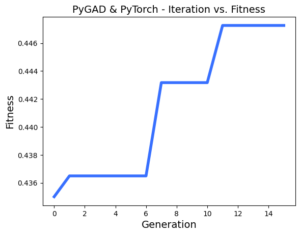

```
Best solution of MLP0 - number of hidden layers: 10:
n_embd = 32.0
n_hidden = 79.0
norm_layer = <class 'torch.nn.modules.batchnorm.BatchNorm1d'>
activation = ReLU()
lr = 0.001
batch_size = 64.0
optimizer = <class 'torch.optim.adam.Adam'>
```

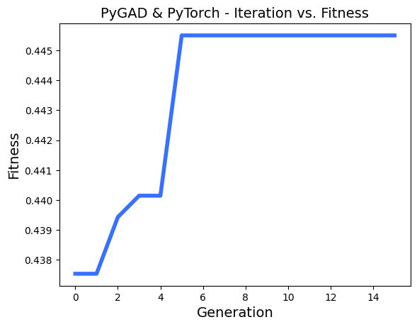

```
Best solution of MLP1 - number of hidden layers: 9:
n_embd = 32.0
n_hidden = 64.0
norm_layer = <class 'torch.nn.modules.normalization.LayerNorm'>
activation = Tanh()
lr = 0.01
batch_size = 64.0
optimizer = <class 'torch.optim.sgd.SGD'>
```

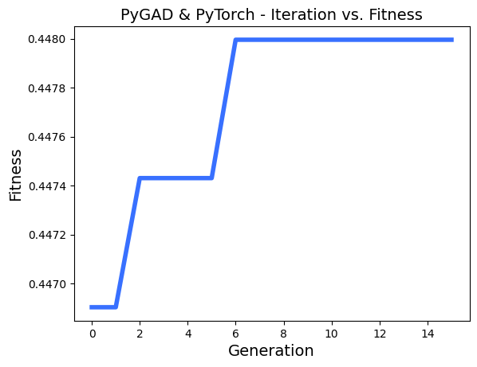

```
Best solution of MLP2 - number of hidden layers: 8:
n_embd = 8.0
n_hidden = 61.0
norm_layer = <class 'torch.nn.modules.batchnorm.BatchNorm1d'>
activation = LeakyReLU(negative_slope=0.01)
lr = 0.1
batch_size = 64.0
optimizer = <class 'torch.optim.sgd.SGD'>
```

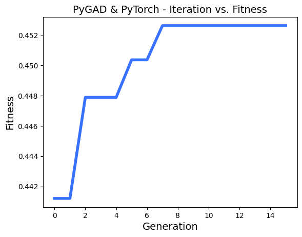

```
Best solution of MLP3 - number of hidden layers: 7:
n_embd = 32.0
n_hidden = 75.0
norm_layer = <class 'torch.nn.modules.batchnorm.BatchNorm1d'>
activation = LeakyReLU(negative_slope=0.01)
lr = 0.001
batch_size = 64.0
optimizer = <class 'torch.optim.adam.Adam'>
```

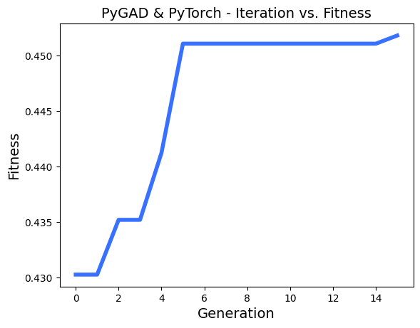

```
Best solution of MLP4 - number of hidden layers: 6:
n_embd = 32.0
n_hidden = 59.0
norm_layer = <class 'torch.nn.modules.batchnorm.BatchNorm1d'>
activation = ReLU()
lr = 0.1
batch_size = 64.0
optimizer = <class 'torch.optim.sgd.SGD'>
```

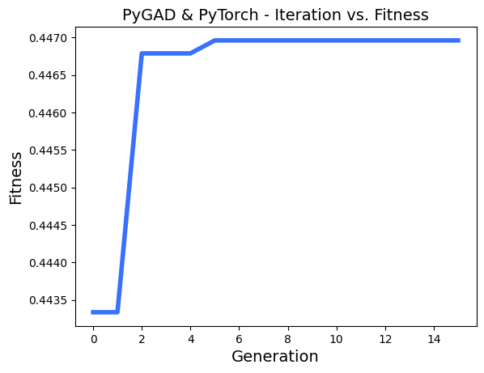

```
Best solution of MLP5 - number of hidden layers: 5:
n_embd = 32.0
n_hidden = 68.0
norm_layer = <class 'torch.nn.modules.normalization.LayerNorm'>
activation = Tanh()
lr = 0.01
batch_size = 64.0
optimizer = <class 'torch.optim.sgd.SGD'>
```

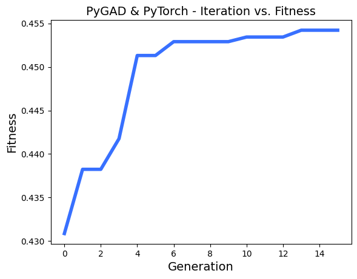

```
Best solution of MLP6 - number of hidden layers: 4:
n_embd = 32.0
n_hidden = 68.0
norm_layer = <class 'torch.nn.modules.batchnorm.BatchNorm1d'>
activation = LeakyReLU(negative_slope=0.01)
lr = 0.001
batch_size = 64.0
optimizer = <class 'torch.optim.adam.Adam'>
```

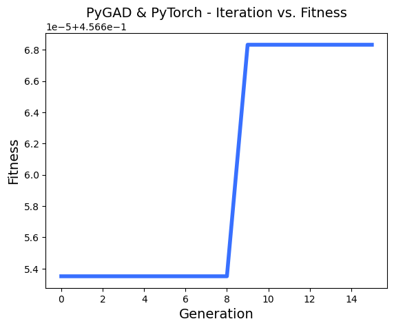

```
Best solution of MLP7 - number of hidden layers: 3:
n_embd = 16.0
n_hidden = 78.0
norm_layer = <class 'torch.nn.modules.batchnorm.BatchNorm1d'>
activation = ReLU()
lr = 0.1
batch_size = 64.0
optimizer = <class 'torch.optim.sgd.SGD'>
```

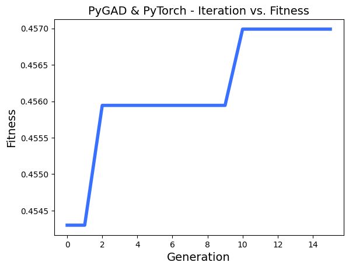

```
Best solution of MLP8 - number of hidden layers: 2:
n_embd = 32.0
n_hidden = 76.0
norm_layer = <class 'torch.nn.modules.batchnorm.BatchNorm1d'>
activation = ReLU()
lr = 0.005
batch_size = 64.0
optimizer = <class 'torch.optim.adam.Adam'>
```

```python
num_generations = 15 # Number of generations.
num_parents_mating = 4 # Number of solutions to be selected as parents in the mating pool.
sol_per_pop = 7
mutation_num_genes = 1
keep_elitism = 2
parent_selection_type = "rws" # Type of parent selection.
crossover_type = "single_point"
gene_space = [
                [8, 16, 32],
                {'low': 16, 'high': 80, 'step': 1},
                [0, 1],
                [0, 1, 2, 3],
                [0.0001, 0.001, 0.005, 0.01, 0.1],
                [16, 32, 64],
                [0, 1],
            ]
num_genes = len(gene_space)

best_fitnesses = []
for i in range(len(inputs)):

    ga_instance = pygad.GA(num_generations=num_generations,
                        num_parents_mating=num_parents_mating,
                        num_genes=num_genes,
                        sol_per_pop=sol_per_pop,
                        keep_elitism=keep_elitism,
                        parent_selection_type=parent_selection_type,
                        fitness_func=fitness_func_factory(inputs[i]),
                        crossover_type=crossover_type,
                        gene_space=gene_space,
                        mutation_num_genes=mutation_num_genes,
                        )

    # Start the genetic algorithm evolution.
    ga_instance.run()

    ga_instance.plot_fitness(title="PyGAD & PyTorch - Iteration vs. Fitness", linewidth=4);
    solution, best_fitness, _ = ga_instance.best_solution()
    n_embd, n_hidden, norm_layer_num, activation_num, lr, batch_size, optimizer_num = solution
    activation = act_map[activation_num]
    norm_layer = norm_map[norm_layer_num]
    best_fitnesses.append(best_fitness)

    print(f"Best solution of MLP{i} - number of hidden layers: {10-i}: \n"
      f"n_embd = {n_embd}\n"
      f"n_hidden = {n_hidden}\n"
      f"norm_layer = {norm_map[norm_layer_num]}\n"
      f"activation = {act_map[activation_num]}\n"
      f"lr = {lr} \n"
      f"batch_size = {batch_size}\n"
      f"optimizer = {optim_map[optimizer_num]}"
    )
```

| Model | n_embd | n_hidden | norm_layer | activation | lr | batch_size | optimizer |
| --- | --- | --- | --- | --- | --- | --- | --- |
| MLP0 | 32 | 79 | BatchNorm | ReLU | 0.001 | 64 | Adam |
| MLP1 | 32 | 64 | LayerNorm | Tanh | 0.01 | 64 | SDG |
| MLP2 | 8 | 61 | BatchNorm | LekayReLU | 0.1 | 64 | SDG |
| MLP3 | 32 | 75 | BatchNorm | LeakyReLU | 0.001 | 64 | Adam |
| MLP4 | 32 | 59 | BatchNorm | ReLU | 0.1 | 64 | SDG |
| MLP5 | 32 | 68 | LayerNorm | Tanh | 0.01 | 64 | SDG |
| MLP6 | 32 | 68 | BatchNorm | LeakyReLU | 0.001 | 64 | Adam |
| MLP7 | 16 | 78 | BatchNorm | ReLU | 0.1 | 64 | SDG |
| MLP8 | 32 | 76 | BatchNorm | ReLU | 0.005 | 64 | Adam |

### Sprawdzenie efektywności algorytmu genetycznego

Badanie efektywności algorytmu genetycznego wedle kryteriów zaprponowanych w opisie projektu jest trochę problematyczne, ponieważ najefektywniejsze rozwiązanie do którego algorytm miałby dążyć nie jest znane.

Zamiast tego porównam model o najlepszej funkcji fitness z modelem o losowo dobranych hiperparametrach. Porówne zostaną trzy modele, po jednym z każdej kategorii wielkości inputów.

```python
def draw_hiperparams():
    n_embd = np.random.choice([8, 16, 32])
    n_hidden = np.random.choice(range(16, 80, 1))
    norm_layer_num = np.random.choice([0, 1])
    activation_num = np.random.choice([0, 1, 2, 3])
    lr = np.random.choice([0.0001, 0.001, 0.005, 0.01, 0.1])
    batch_size = np.random.choice([16, 32, 64])
    optimizer_num = np.random.choice([0, 1])
    return n_embd, n_hidden, norm_layer_num, activation_num, lr, batch_size, optimizer_num
```

```python
def training_loop(n_embd, n_hidden, norm_layer_num, activation_num, lr, batch_size, optimizer_num, model):
    activation = act_map[activation_num]
    norm_layer = norm_map[norm_layer_num]
    bias = True if int(norm_layer_num) == 1 else False
    model = model(vocab_size, n_embd, n_hidden, bias, norm_layer, activation)
    optimizer = optim_map[optimizer_num](params=model.parameters(), lr=lr)
    loss_function = torch.nn.CrossEntropyLoss()
    g = torch.Generator().manual_seed(2147483647)

    step_arr, dev_loss_arr = [], []
    steps = 15000
    start = time.time()
    for step in range(steps):
        if step == 8000:
            optimizer.param_groups[0]['lr'] = lr * 0.7
        elif step == 13000:
            optimizer.param_groups[0]['lr'] = lr * 0.5

        inx = torch.randint(0, training_set.shape[0], (int(batch_size),), generator=g)
        emb = training_set[inx] # grab only those rows from the minibatch

        optimizer.zero_grad(set_to_none=True)

        # forward pass
        preds = model(emb)
        loss = loss_function(preds, y_training_set[inx])

        # backward pass
        loss.backward()

        # update the weights
        optimizer.step()

        #stats
        if step % 250 == 0:
            dev_loss = get_loss(model, 'dev')
            dev_loss_arr.append(dev_loss)
            step_arr.append(step)

    end = time.time()
    training_time = round(end - start, 2)

    return training_time, step_arr, dev_loss_arr
```

#### Mały input

```
Random MLP training time: 127.9 seconds
MLP7 training time: 88.09 seconds
```

[figure not shown]

```python
n_embd, n_hidden, norm_layer_num, activation_num, lr, batch_size, optimizer_num = draw_hiperparams()
rand_train_time, rand_step, rand_loss = training_loop(n_embd, n_hidden, norm_layer_num, activation_num, lr, batch_size, optimizer_num, MLP8)

train_time, step, loss = training_loop(32, 76, 0, 0, 0.005, 64, 0, MLP8)

print(f"Random MLP training time: {rand_train_time} seconds")
print(f"MLP7 training time: {train_time} seconds")
plt.plot(rand_step, rand_loss, label='Random MLP');
plt.plot(step, loss, label='MLP8');
plt.xlabel('Step')
plt.ylabel('Dev Loss')
plt.legend();
```

#### Średni input

```
Random MLP training time: 107.9 seconds
MLP4 training time: 137.49 seconds
```

[figure not shown]

```python
n_embd, n_hidden, norm_layer_num, activation_num, lr, batch_size, optimizer_num = draw_hiperparams()
rand_train_time, rand_step, rand_loss = training_loop(n_embd, n_hidden, norm_layer_num, activation_num, lr, batch_size, optimizer_num, MLP3)

train_time, step, loss = training_loop(32, 75, 0, 2, 0.001, 64, 0, MLP3)

print(f"Random MLP training time: {rand_train_time} seconds")
print(f"MLP4 training time: {train_time} seconds")
plt.plot(rand_step, rand_loss, label='Random MLP');
plt.plot(step, loss, label='MLP3');
plt.xlabel('Step')
plt.ylabel('Dev Loss')
plt.legend();
```

#### Duży input

```
Random MLP training time: 258.26 seconds
MLP1 training time: 228.12 seconds
```

[figure not shown]

```python
n_embd, n_hidden, norm_layer_num, activation_num, lr, batch_size, optimizer_num = draw_hiperparams()
rand_train_time, rand_step, rand_loss = training_loop(n_embd, n_hidden, norm_layer_num, activation_num, lr, batch_size, optimizer_num, MLP0)

train_time, step, loss = training_loop(32, 79, 0, 0, 0.001, 64, 0, MLP0)

print(f"Random MLP training time: {rand_train_time} seconds")
print(f"MLP1 training time: {train_time} seconds")
plt.plot(rand_step, rand_loss, label='Random MLP');
plt.plot(step, loss, label='MLP0');
plt.xlabel('Step')
plt.ylabel('Dev Loss')
plt.legend();
```

### Wnioski z Eksperymentu1

Dla każdej klasy inputów algorytm genetyczny stworzył lepszy model, niż model o losowo dobranych parametrach. Lepszy w tym kontekście oznacza to, że model zbiegał szybciej do minimum i jego trening trwał krócej (za wyjątkiem modelu ze średnim inputem, którego trening trwał trochę dłużej).

### Eksperyment 2

Zmiany w stosunku do algorytmu z Eksperymentu 1:

- parent_selection_type = "rws" ---> parent_selection_type = "sss"
- crossover_type = "single_point" ---> crossover_type = "two_points"
- z grona funkcji aktywacji usunięto sigmoid
- funkcja fitness uległa małej modyfikacji. Tym razem zwracana jest wartość obliczna ze wzoru:
  - **1.0 / (loss(*zbiór ewaluacyjny*) + (0.001 * training_time))** \

  , gdzie training time to czas przez jaki model był trenowany.

W przypadku algorytmu z Eksperymentu 1 każdy model jest trenowany przez zaledwie 1 epokę (jest to spowodowane ograniczeniami czasowymi). Oznacza to, że modele raczej nie mają szansy na znalezienia globalnego minimum i de facto oceniane są jedynie na podstawie tego, jak szybko są w stanie osiągnąć jak najmniejszą wartość dla funkcji straty w ciągu 1 epoki. Oznacza to m.in, że:

- faworyzowane są modele o większym rozmiarze batcha
- czas potrzebny na trening jest ignorowany

W celu uwzględnienia tego dodano parametr *training_time*.

```python
def fitness_func_factory(inp_model):
    def fitness_func(solution, sol_idx):
        n_embd, n_hidden, norm_layer_num, activation_num, lr, batch_size, optimizer_num = solution
        bias = True if int(norm_layer_num) == 1 else False
        activation = act_map[activation_num]
        norm_layer = norm_map[norm_layer_num]

        model = inp_model(vocab_size, int(n_embd), int(n_hidden), bias, norm_layer, activation)

        optimizer = optim_map[optimizer_num](params=model.parameters(), lr=lr)

        loss_function = torch.nn.CrossEntropyLoss()
        g = torch.Generator().manual_seed(2147483647)
        steps = 5704
        start = time.time()
        for _ in range(steps):
            inx = torch.randint(0, training_set.shape[0], (int(batch_size),), generator=g)
            emb = training_set[inx] # grab only those rows from the minibatch

            optimizer.zero_grad(set_to_none=True)

            # forward pass
            preds = model(emb)
            loss = loss_function(preds, y_training_set[inx])

            # backward pass
            loss.backward()

            # update the weights
            optimizer.step()
        end = time.time()
        training_time = round(end - start, 2)
        dev_loss = get_loss(model, 'dev')
        return 1.0 / (dev_loss + (0.001 * training_time))

    return fitness_func
```

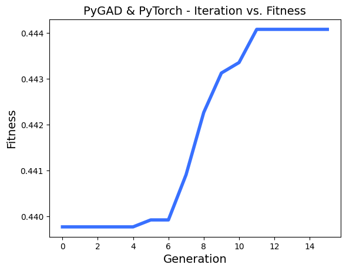

```
Best solution of MLP0 - number of hidden layers: 10:
n_embd = 16.0
n_hidden = 74.0
norm_layer = <class 'torch.nn.modules.batchnorm.BatchNorm1d'>
activation = LeakyReLU(negative_slope=0.01)
lr = 0.1
batch_size = 64.0
optimizer = <class 'torch.optim.sgd.SGD'>
```

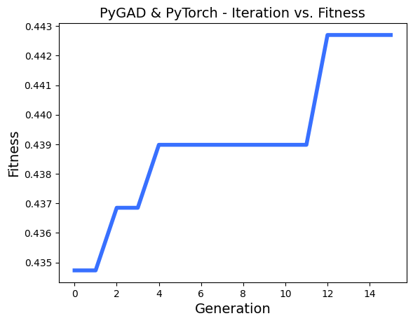

```
Best solution of MLP1 - number of hidden layers: 9:
n_embd = 16.0
n_hidden = 75.0
norm_layer = <class 'torch.nn.modules.batchnorm.BatchNorm1d'>
activation = Tanh()
lr = 0.001
batch_size = 64.0
optimizer = <class 'torch.optim.adam.Adam'>
```

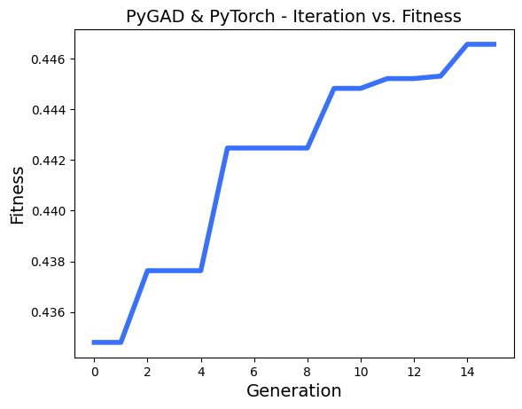

```
Best solution of MLP2 - number of hidden layers: 8:
n_embd = 32.0
n_hidden = 68.0
norm_layer = <class 'torch.nn.modules.normalization.LayerNorm'>
activation = Tanh()
lr = 0.01
batch_size = 64.0
optimizer = <class 'torch.optim.sgd.SGD'>
```

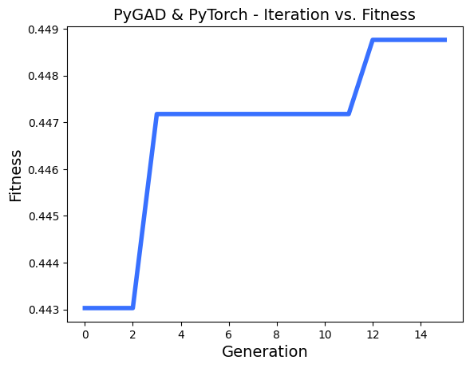

```
Best solution of MLP3 - number of hidden layers: 7:
n_embd = 32.0
n_hidden = 58.0
norm_layer = <class 'torch.nn.modules.batchnorm.BatchNorm1d'>
activation = ReLU()
lr = 0.1
batch_size = 64.0
optimizer = <class 'torch.optim.sgd.SGD'>
```

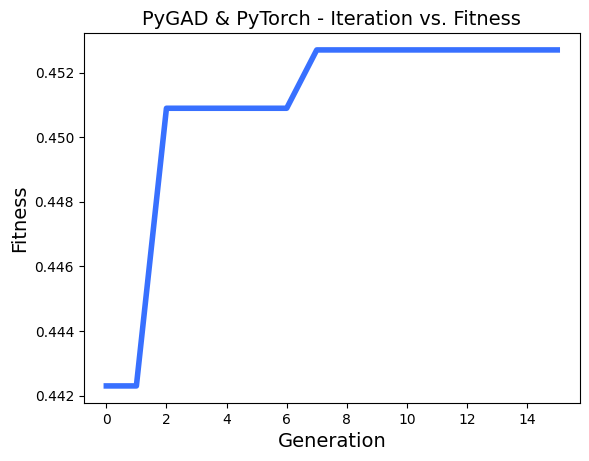

```
Best solution of MLP4 - number of hidden layers: 6:
n_embd = 32.0
n_hidden = 77.0
norm_layer = <class 'torch.nn.modules.batchnorm.BatchNorm1d'>
activation = ReLU()
lr = 0.1
batch_size = 64.0
optimizer = <class 'torch.optim.sgd.SGD'>
```

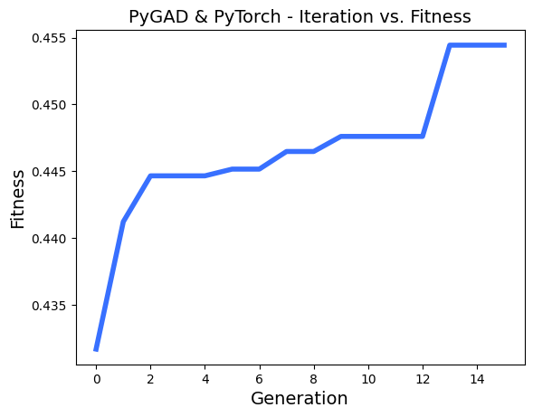

```
Best solution of MLP5 - number of hidden layers: 5:
n_embd = 32.0
n_hidden = 72.0
norm_layer = <class 'torch.nn.modules.batchnorm.BatchNorm1d'>
activation = LeakyReLU(negative_slope=0.01)
lr = 0.1
batch_size = 64.0
optimizer = <class 'torch.optim.sgd.SGD'>
```

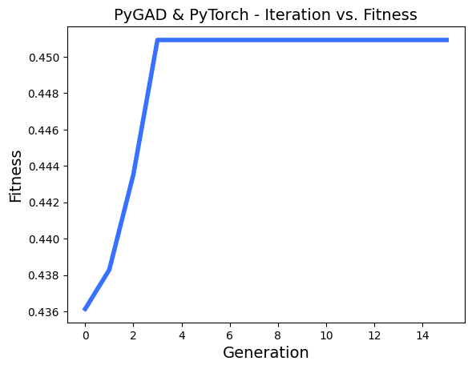

```
Best solution of MLP6 - number of hidden layers: 4:
n_embd = 16.0
n_hidden = 61.0
norm_layer = <class 'torch.nn.modules.batchnorm.BatchNorm1d'>
activation = Tanh()
lr = 0.005
batch_size = 64.0
optimizer = <class 'torch.optim.adam.Adam'>
```

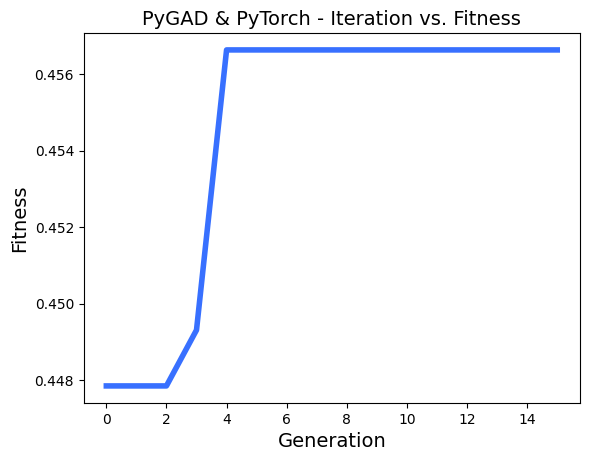

```
Best solution of MLP7 - number of hidden layers: 3:
n_embd = 32.0
n_hidden = 69.0
norm_layer = <class 'torch.nn.modules.batchnorm.BatchNorm1d'>
activation = ReLU()
lr = 0.1
batch_size = 64.0
optimizer = <class 'torch.optim.sgd.SGD'>
```

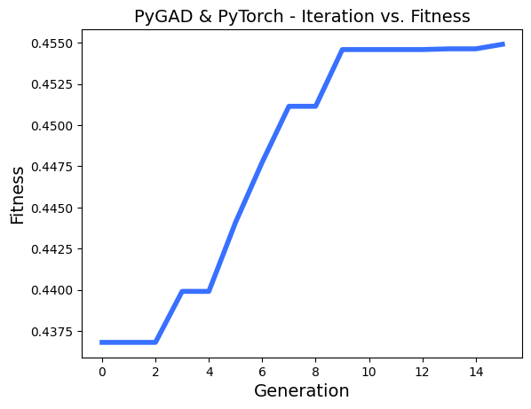

```
Best solution of MLP8 - number of hidden layers: 2:
n_embd = 32.0
n_hidden = 62.0
norm_layer = <class 'torch.nn.modules.batchnorm.BatchNorm1d'>
activation = ReLU()
lr = 0.005
batch_size = 64.0
optimizer = <class 'torch.optim.adam.Adam'>
```

```python
num_generations = 15 # Number of generations.
num_parents_mating = 4 # Number of solutions to be selected as parents in the mating pool.
sol_per_pop = 7
mutation_num_genes = 1
parent_selection_type = "sss" # Type of parent selection.
crossover_type = "two_points"
gene_space = [
                [8, 16, 32],
                {'low': 16, 'high': 80, 'step': 1},
                [0, 1],
                [0, 1, 2],
                [0.0001, 0.001, 0.005, 0.01, 0.1],
                [16, 32, 64],
                [0, 1],
            ]
num_genes = len(gene_space)

best_fitnesses = []
for i in range(len(inputs)):

    ga_instance = pygad.GA(num_generations=num_generations,
                        num_parents_mating=num_parents_mating,
                        num_genes=num_genes,
                        sol_per_pop=sol_per_pop,
                        parent_selection_type=parent_selection_type,
                        fitness_func=fitness_func_factory(inputs[i]),
                        crossover_type=crossover_type,
                        gene_space=gene_space,
                        mutation_num_genes=mutation_num_genes,
                        )

    # Start the genetic algorithm evolution.
    ga_instance.run()

    ga_instance.plot_fitness(title="PyGAD & PyTorch - Iteration vs. Fitness", linewidth=4);
    solution, best_fitness, _ = ga_instance.best_solution()
    n_embd, n_hidden, norm_layer_num, activation_num, lr, batch_size, optimizer_num = solution
    activation = act_map[activation_num]
    norm_layer = norm_map[norm_layer_num]
    best_fitnesses.append(best_fitness)

    print(f"Best solution of MLP{i} - number of hidden layers: {10-i}: \n"
      f"n_embd = {n_embd}\n"
      f"n_hidden = {n_hidden}\n"
      f"norm_layer = {norm_map[norm_layer_num]}\n"
      f"activation = {act_map[activation_num]}\n"
      f"lr = {lr}\n"
      f"batch_size = {batch_size}\n"
      f"optimizer = {optim_map[optimizer_num]}"
    )
```

| Model | n_embd | n_hidden | norm_layer | activation | lr | batch_size | optimizer |
| --- | --- | --- | --- | --- | --- | --- | --- |
| MLP0 | 16 | 74 | BatchNorm | LeakyReLU | 0.1 | 64 | SGD |
| MLP1 | 16 | 75 | BatchNorm | Tanh | 0.001 | 64 | Adam |
| MLP2 | 32 | 68 | LayerNorm | Tanh | 0.01 | 64 | SGD |
| MLP3 | 32 | 58 | BatchNorm | ReLU | 0.1 | 64 | SGD |
| MLP4 | 32 | 77 | BatchNorm | ReLU | 0.1 | 64 | SGD |
| MLP5 | 32 | 72 | BatchNorm | LeakyReLU | 0.1 | 64 | SGD |
| MLP6 | 16 | 61 | BatchNorm | Tanh | 0.005 | 64 | Adam |
| MLP7 | 32 | 69 | BatchNorm | ReLU | 0.1 | 64 | SGD |
| MLP8 | 32 | 62 | BatchNorm | ReLU | 0.005 | 64 | Adam |

### Porównanie efektywności algorytmu genetycznego

Metodologia analogiczna do tej z Eksperymentu 1

```python
inp_fit_pairs = list(zip(inputs, best_fitnesses))
for i in range(len(inputs)):
    if i == 0:
        print("Large Inputs:")
    elif i == 3:
        print("Medium Inputs:")
    elif i == 6:
        print("Small Inputs:")
    print(f"    MLP{i} - fitness: {inp_fit_pairs[i][1]}")
```

```
Large Inputs:
    MLP0 - fitness: 0.4440758167192871
    MLP1 - fitness: 0.4426989356448938
    MLP2 - fitness: 0.4465608200213782
Medium Inputs:
    MLP3 - fitness: 0.44876240260135625
    MLP4 - fitness: 0.45269933564203835
    MLP5 - fitness: 0.45443485335148887
Small Inputs:
    MLP6 - fitness: 0.4509285099853427
    MLP7 - fitness: 0.45663036383832756
    MLP8 - fitness: 0.45504146290719993
```

```python
def draw_hiperparams():
    n_embd = np.random.choice([8, 16, 32])
    n_hidden = np.random.choice(range(16, 81, 1))
    norm_layer_num = np.random.choice([0, 1])
    activation_num = np.random.choice([0, 1, 2])
    lr = np.random.choice([0.0001, 0.001, 0.005, 0.01, 0.1])
    batch_size = np.random.choice([16, 32, 64])
    optimizer_num = np.random.choice([0, 1])
    return n_embd, n_hidden, norm_layer_num, activation_num, lr, batch_size, optimizer_num
```

#### Mały input

```
Random MLP training time: 133.26 seconds
MLP7 training time: 55.63 seconds
```

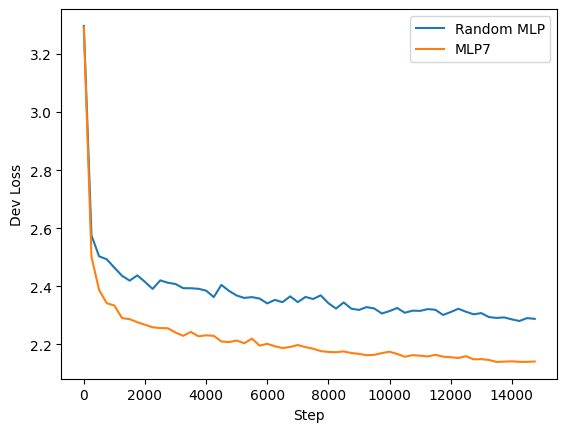

```python
n_embd, n_hidden, norm_layer_num, activation_num, lr, batch_size, optimizer_num = draw_hiperparams()
rand_train_time, rand_step, rand_loss = training_loop(n_embd, n_hidden, norm_layer_num, activation_num, lr, batch_size, optimizer_num, MLP7)

train_time, step, loss = training_loop(32, 69, 0, 0, 0.1, 64, 1, MLP7)

print(f"Random MLP training time: {rand_train_time} seconds")
print(f"MLP7 training time: {train_time} seconds")
plt.plot(rand_step, rand_loss, label='Random MLP');
plt.plot(step, loss, label='MLP7');
plt.xlabel('Step')
plt.ylabel('Dev Loss')
plt.legend();
```

#### Średni input

```
Random MLP training time: 115.12 seconds
MLP4 training time: 58.04 seconds
```

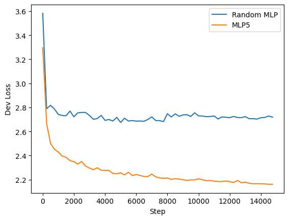

```python
n_embd, n_hidden, norm_layer_num, activation_num, lr, batch_size, optimizer_num = draw_hiperparams()
rand_train_time, rand_step, rand_loss = training_loop(n_embd, n_hidden, norm_layer_num, activation_num, lr, batch_size, optimizer_num, MLP5)

train_time, step, loss = training_loop(32, 72, 0, 2, 0.1, 64, 1, MLP5)

print(f"Random MLP training time: {rand_train_time} seconds")
print(f"MLP4 training time: {train_time} seconds")
plt.plot(rand_step, rand_loss, label='Random MLP');
plt.plot(step, loss, label='MLP5');
plt.xlabel('Step')
plt.ylabel('Dev Loss')
plt.legend();
```

#### Duży input

```
Random MLP training time: 77.02 seconds
MLP1 training time: 135.84 seconds
```

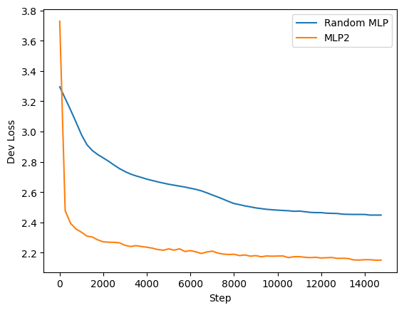

```python
n_embd, n_hidden, norm_layer_num, activation_num, lr, batch_size, optimizer_num = draw_hiperparams()
rand_train_time, rand_step, rand_loss = training_loop(n_embd, n_hidden, norm_layer_num, activation_num, lr, batch_size, optimizer_num, MLP2)

train_time, step, loss = training_loop(32, 68, 1, 1, 0.01, 64, 1, MLP2)

print(f"Random MLP training time: {rand_train_time} seconds")
print(f"MLP1 training time: {train_time} seconds")
plt.plot(rand_step, rand_loss, label='Random MLP');
plt.plot(step, loss, label='MLP2');
plt.xlabel('Step')
plt.ylabel('Dev Loss')
plt.legend();
```

### Wnioski z Eksperymentu2

Dla każdej klasy inputów algorytm genetyczny stworzył lepszy model, niż model o losowo dobranych parametrach. Lepszy w tym kontekście oznacza to, że model zbiegał szybciej do minimum i jego trening trwał krócej (za wyjątkiem modelu z dużym inputem, którego trening trwał dłużej).

W porównaniu z Eksperymentem1 Eksperyment2 dał praktycznie takie same rezultaty za wyjątkiem tego, że trening modeli z Eksperymentu2 odbywał się trochę szybciej (może waga parametru *training_time* mimo wszystko była zbyt mała?).

### Kilka próbek z modelu o najlepszych hiperparametrach

```
Training time: 226.91 seconds
Final train loss: 2.0417637825012207
Final dev loss: 2.1049695014953613
Final test loss: 2.1205146312713623
```

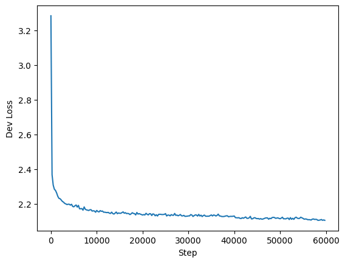

```python
n_embd, n_hidden, norm_layer_num, activation_num, lr, batch_size, optimizer_num = 32, 76, 0, 0, 0.005, 64, 0

# train
activation = act_map[activation_num]
norm_layer = norm_map[norm_layer_num]
bias = True if int(norm_layer_num) == 1 else False
model = MLP8(vocab_size, n_embd, n_hidden, bias, norm_layer, activation)
optimizer = optim_map[optimizer_num](params=model.parameters(), lr=lr)
loss_function = torch.nn.CrossEntropyLoss()
g = torch.Generator().manual_seed(2147483647)

step_arr, dev_loss_arr = [], []
steps = 60000
start = time.time()
for step in range(steps):
    if step == 40000:
        optimizer.param_groups[0]['lr'] = lr * 0.7
    elif step == 55000:
        optimizer.param_groups[0]['lr'] = lr * 0.5

    inx = torch.randint(0, training_set.shape[0], (int(batch_size),), generator=g)
    emb = training_set[inx] # grab only those rows from the minibatch

    optimizer.zero_grad(set_to_none=True)

    # forward pass
    preds = model(emb)
    loss = loss_function(preds, y_training_set[inx])

    # backward pass
    loss.backward()

    # update the weights
    optimizer.step()

    #stats
    if step % 250 == 0:
        dev_loss = get_loss(model, 'dev')
        dev_loss_arr.append(dev_loss)
        step_arr.append(step)

end = time.time()
training_time = round(end - start, 2)

plt.plot(step_arr, dev_loss_arr);
plt.xlabel('Step')
plt.ylabel('Dev Loss');
print(f"Training time: {training_time} seconds")
print(f"Final train loss: {get_loss(model, 'train')}")
print(f"Final dev loss: {dev_loss_arr[-1]}")
print(f"Final test loss: {get_loss(model, 'test')}")
```

```python
# sample from the best model
model.eval()
@torch.no_grad()
def sample(model):
	g = torch.Generator().manual_seed(2147483647 + 10)
	for _ in range(20):
		out = '.' * block_size
		while True:
			x = torch.tensor([str_to_inx[x] for x in out[-block_size:]])
			x = x.view(1, -1)
			logits = model(x)
			probs = F.softmax(logits, dim=1)
			inx = torch.multinomial(probs, num_samples=1, generator=g).item()
			out = out + inx_to_str[inx]
			if inx == 0:
				break

		print(out.replace('.', ''))
print('Samples from the best model:')
sample(model)
```

```
Samples from the best model:
montaimyah
seel
nihayla
rethruthja
leg
adeer
melin
shi
jen
eden
estanar
kayzion
kalin
shub
ridhimier
kin
renelionnie
cayus
mace
ruyah
```

### Bibliografia

https://www.jstage.jst.go.jp/article/abe/9/0/9_9_225/_pdf/-char/en https://www.researchgate.net/publication/342408663_Efficient_Hyperparameter_Optimization_in_Deep_Learning_Using_a_Variable_Length_Genetic_Algorithm https://www.mdpi.com/2079-9292/11/21/3591 https://blog.derlin.ch/genetic-algorithms-with-pygad#heading-rank-selection-rank